# Assignment 3

## Regression

Please find attached to Module 3 on Canvas the file labeled "train.parquet". This assignment will require to select and train a regression model to predict the column labeled 'Electricity imported from grid (kW)'. You will evaluate your model using out-of-sample R-squared on the dataset labeled "test.parquet". Refer to the class slides for a description of the training and testing data. Upload this notebook to Canvas as HTML and IPYNB files.

### Modeling

Follow prompts below in python comments

```python
# import libraries

import pandas as pd
import numpy as np
import json
import os
import time
import matplotlib.pyplot as plt
import seaborn as sns
from sklearn.preprocessing import StandardScaler
from datetime import datetime
from sklearn.model_selection import train_test_split
from sklearn.model_selection import GridSearchCV, TimeSeriesSplit
from sklearn.ensemble import RandomForestClassifier, RandomForestRegressor, GradientBoostingClassifier, GradientBoostingRegressor
from sklearn.metrics import accuracy_score, precision_score, recall_score, f1_score, confusion_matrix, r2_score, mean_squared_error, mean_absolute_error
from sklearn.preprocessing import LabelEncoder
import plotly.express as px
import plotly.graph_objects as go
from plotly.subplots import make_subplots
from statsmodels.graphics.tsaplots import plot_acf, plot_pacf
```

```python
# load training dataset
train_df = pd.read_parquet('train.parquet')

# quick look at the data
print(train_df.head())
print(f"\nDataset shape: {train_df.shape}")
print(f"\nColumn info:")
print(train_df.info())
print(f"\nSUMMARY:")
print(f"Business records: {len(train_df):,}")
```

```
                     Electricity imported from grid (kW)  \
Date
2001-06-01 00:00:00                                249.0
2001-06-01 01:00:00                                254.0
2001-06-01 02:00:00                                223.0
2001-06-01 03:00:00                                232.0
2001-06-01 04:00:00                                235.0

                     Horizontal solar irradition (W)  \
Date
2001-06-01 00:00:00                              0.0
2001-06-01 01:00:00                              0.0
2001-06-01 02:00:00                              0.0
2001-06-01 03:00:00                              0.0
2001-06-01 04:00:00                              0.0

                     Outdoor air temperature (℃)  Outdoor air humidity (%)  \
Date
2001-06-01 00:00:00                         17.9                      66.0
2001-06-01 01:00:00                         17.5                      70.0
2001-06-01 02:00:00                         17.1                      73.0
2001-06-01 03:00:00                         16.8                      75.0
2001-06-01 04:00:00                         16.8                      74.0

                     Wind speed (m/s)  Wind direction
Date
2001-06-01 00:00:00               2.3           188.0
2001-06-01 01:00:00               1.9           183.0
2001-06-01 02:00:00               3.1           156.0
2001-06-01 03:00:00               0.4           215.0
2001-06-01 04:00:00               0.7           143.0

Dataset shape: (146621, 6)

Column info:
<class 'pandas.core.frame.DataFrame'>
DatetimeIndex: 146621 entries, 2001-06-01 00:00:00 to 2018-02-21 04:00:00
Data columns (total 6 columns):
 #   Column                               Non-Null Count   Dtype
---  ------                               --------------   -----
 0   Electricity imported from grid (kW)  146621 non-null  float64
 1   Horizontal solar irradition (W)      146621 non-null  float64
 2   Outdoor air temperature (℃)          146621 non-null  float64
 3   Outdoor air humidity (%)             146621 non-null  float64
 4   Wind speed (m/s)                     146621 non-null  float64
 5   Wind direction                       146621 non-null  float64
dtypes: float64(6)
memory usage: 7.8 MB
None

SUMMARY:
Business records: 146,621
```

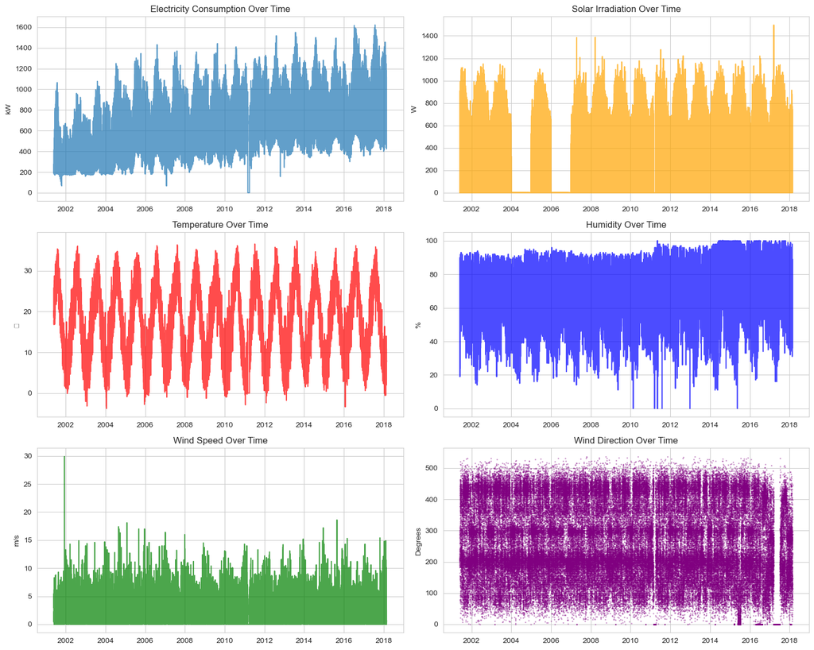

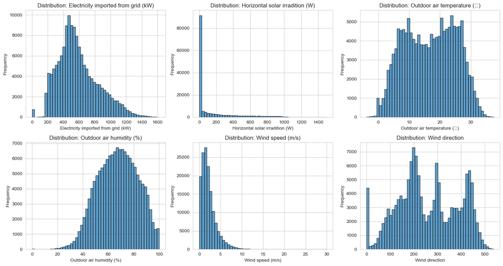

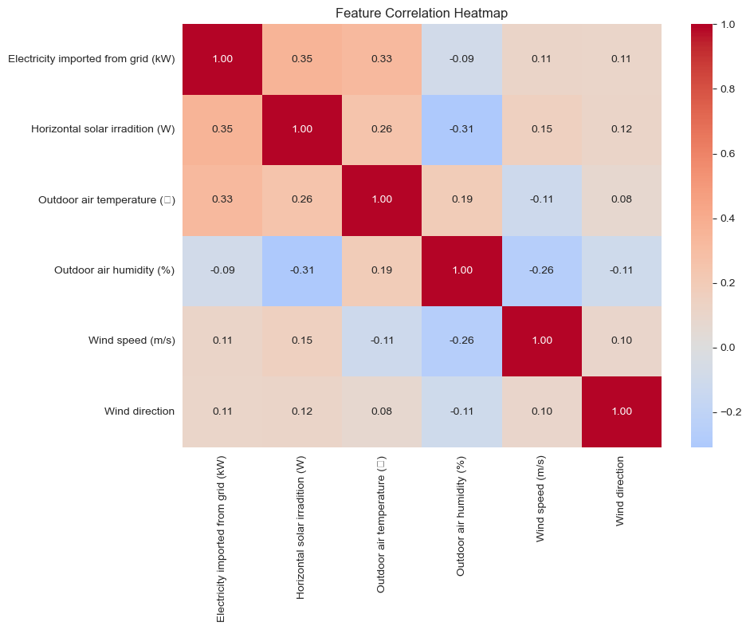

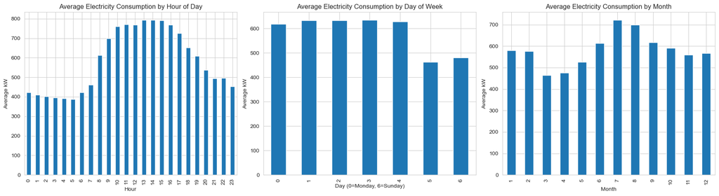

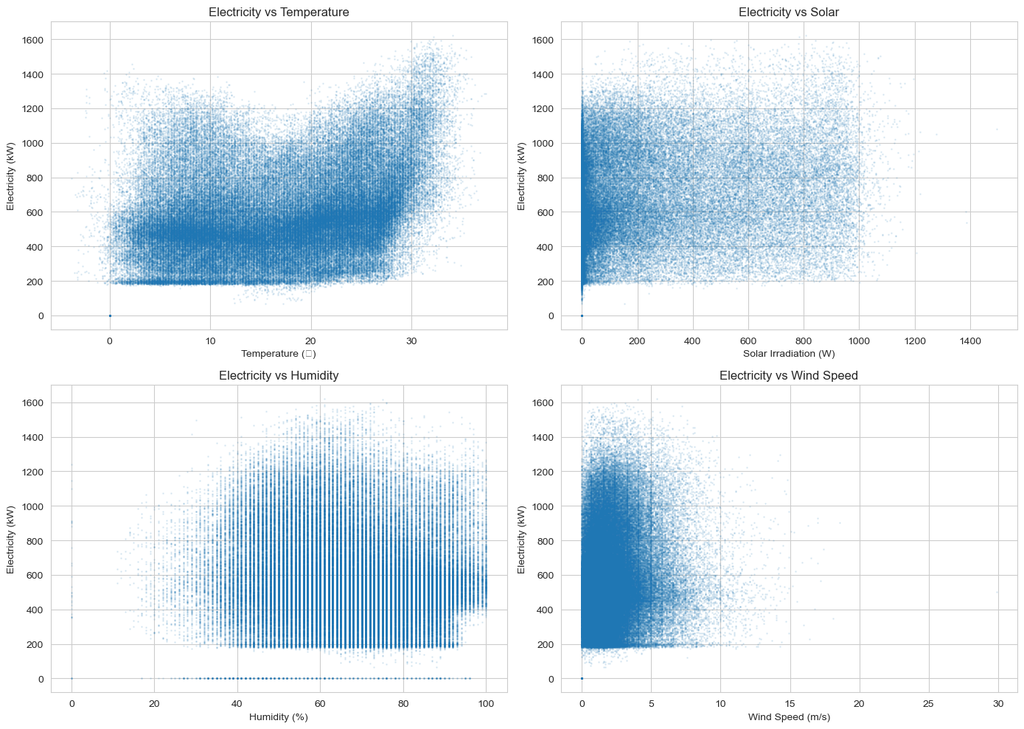

```python
# data visualization

# Set style
sns.set_style("whitegrid")

# ========== 1. TIME SERIES PLOTS ==========
fig, axes = plt.subplots(3, 2, figsize=(15, 12))

# Electricity consumption over time
axes[0, 0].plot(train_df.index, train_df['Electricity imported from grid (kW)'], alpha=0.7)
axes[0, 0].set_title('Electricity Consumption Over Time')
axes[0, 0].set_ylabel('kW')

# Solar irradiation over time
axes[0, 1].plot(train_df.index, train_df['Horizontal solar irradition (W)'], alpha=0.7, color='orange')
axes[0, 1].set_title('Solar Irradiation Over Time')
axes[0, 1].set_ylabel('W')

# Temperature over time
axes[1, 0].plot(train_df.index, train_df['Outdoor air temperature (℃)'], alpha=0.7, color='red')
axes[1, 0].set_title('Temperature Over Time')
axes[1, 0].set_ylabel('℃')

# Humidity over time
axes[1, 1].plot(train_df.index, train_df['Outdoor air humidity (%)'], alpha=0.7, color='blue')
axes[1, 1].set_title('Humidity Over Time')
axes[1, 1].set_ylabel('%')

# Wind speed over time
axes[2, 0].plot(train_df.index, train_df['Wind speed (m/s)'], alpha=0.7, color='green')
axes[2, 0].set_title('Wind Speed Over Time')
axes[2, 0].set_ylabel('m/s')

# Wind direction over time
axes[2, 1].scatter(train_df.index, train_df['Wind direction'], alpha=0.3, s=1, color='purple')
axes[2, 1].set_title('Wind Direction Over Time')
axes[2, 1].set_ylabel('Degrees')

plt.tight_layout()
plt.show()

# ========== 2. DISTRIBUTION PLOTS ==========
fig, axes = plt.subplots(2, 3, figsize=(15, 8))

for idx, col in enumerate(train_df.columns):
    row = idx // 3
    col_idx = idx % 3
    axes[row, col_idx].hist(train_df[col], bins=50, edgecolor='black', alpha=0.7)
    axes[row, col_idx].set_title(f'Distribution: {col}')
    axes[row, col_idx].set_xlabel(col)
    axes[row, col_idx].set_ylabel('Frequency')

plt.tight_layout()
plt.show()

# ========== 3. CORRELATION HEATMAP ==========
plt.figure(figsize=(10, 8))
correlation_matrix = train_df.corr()
sns.heatmap(correlation_matrix, annot=True, cmap='coolwarm', center=0, fmt='.2f')
plt.title('Feature Correlation Heatmap')
plt.tight_layout()
plt.show()

# ========== 4. TEMPORAL PATTERNS ==========
fig, axes = plt.subplots(1, 3, figsize=(18, 5))

# Hourly pattern
train_df.groupby(train_df.index.hour)['Electricity imported from grid (kW)'].mean().plot(kind='bar', ax=axes[0])
axes[0].set_title('Average Electricity Consumption by Hour of Day')
axes[0].set_xlabel('Hour')
axes[0].set_ylabel('Average kW')

# Daily pattern
train_df.groupby(train_df.index.dayofweek)['Electricity imported from grid (kW)'].mean().plot(kind='bar', ax=axes[1])
axes[1].set_title('Average Electricity Consumption by Day of Week')
axes[1].set_xlabel('Day (0=Monday, 6=Sunday)')
axes[1].set_ylabel('Average kW')

# Monthly pattern
train_df.groupby(train_df.index.month)['Electricity imported from grid (kW)'].mean().plot(kind='bar', ax=axes[2])
axes[2].set_title('Average Electricity Consumption by Month')
axes[2].set_xlabel('Month')
axes[2].set_ylabel('Average kW')

plt.tight_layout()
plt.show()

# ========== 5. FEATURE RELATIONSHIPS WITH TARGET ==========
fig, axes = plt.subplots(2, 2, figsize=(14, 10))

axes[0, 0].scatter(train_df['Outdoor air temperature (℃)'],
                   train_df['Electricity imported from grid (kW)'], alpha=0.1, s=1)
axes[0, 0].set_xlabel('Temperature (℃)')
axes[0, 0].set_ylabel('Electricity (kW)')
axes[0, 0].set_title('Electricity vs Temperature')

axes[0, 1].scatter(train_df['Horizontal solar irradition (W)'],
                   train_df['Electricity imported from grid (kW)'], alpha=0.1, s=1)
axes[0, 1].set_xlabel('Solar Irradiation (W)')
axes[0, 1].set_ylabel('Electricity (kW)')
axes[0, 1].set_title('Electricity vs Solar')

axes[1, 0].scatter(train_df['Outdoor air humidity (%)'],
                   train_df['Electricity imported from grid (kW)'], alpha=0.1, s=1)
axes[1, 0].set_xlabel('Humidity (%)')
axes[1, 0].set_ylabel('Electricity (kW)')
axes[1, 0].set_title('Electricity vs Humidity')

axes[1, 1].scatter(train_df['Wind speed (m/s)'],
                   train_df['Electricity imported from grid (kW)'], alpha=0.1, s=1)
axes[1, 1].set_xlabel('Wind Speed (m/s)')
axes[1, 1].set_ylabel('Electricity (kW)')
axes[1, 1].set_title('Electricity vs Wind Speed')

plt.tight_layout()
plt.show()
```

```python
# feature engineering

model_df = train_df.copy()

# ========== 1. TEMPORAL FEATURES ==========
# Keep only features NOT encoded cyclically
model_df['day_of_month'] = model_df.index.day
model_df['week_of_year'] = model_df.index.isocalendar().week
model_df['is_weekend'] = (model_df.index.dayofweek >= 5).astype(int)

# ========== 2. CYCLICAL FEATURES ==========
# Hour encoding (24-hour cycle) - DROP raw 'hour'
model_df['hour_sin'] = np.sin(2 * np.pi * model_df.index.hour / 24)
model_df['hour_cos'] = np.cos(2 * np.pi * model_df.index.hour / 24)

# Month encoding (12-month cycle) - DROP raw 'month'
model_df['month_sin'] = np.sin(2 * np.pi * model_df.index.month / 12)
model_df['month_cos'] = np.cos(2 * np.pi * model_df.index.month / 12)

# Day of week encoding (7-day cycle) - DROP raw 'day_of_week'
model_df['day_sin'] = np.sin(2 * np.pi * model_df.index.dayofweek / 7)
model_df['day_cos'] = np.cos(2 * np.pi * model_df.index.dayofweek / 7)

# ========== 3. LAG FEATURES (REDUCED) ==========
target_col = 'Electricity imported from grid (kW)'

# Keep most important lags only
model_df['electricity_lag_1h'] = model_df[target_col].shift(1)
model_df['electricity_lag_24h'] = model_df[target_col].shift(24)
model_df['electricity_lag_168h'] = model_df[target_col].shift(168)

# ========== 4. ROLLING STATISTICS ==========
# Rolling mean - past 24 hours
model_df['electricity_rolling_mean_24h'] = model_df[target_col].shift(1).rolling(window=24).mean()

# Rolling std - past 24 hours
model_df['electricity_rolling_std_24h'] = model_df[target_col].shift(1).rolling(window=24).std()

# Rolling mean - past 7 days
model_df['electricity_rolling_mean_7d'] = model_df[target_col].shift(1).rolling(window=168).mean()

# ========== 5. INTERACTION FEATURES (REDUCED) ==========
# Keep only temperature squared (most important non-linear relationship)
model_df['temp_squared'] = model_df['Outdoor air temperature (℃)'] ** 2

# ========== 6. DROP ROWS WITH NaN ==========
print(f"Original shape: {model_df.shape}")
print(f"Missing values before dropping:\n{model_df.isnull().sum()}")

model_df = model_df.dropna()

print(f"\nShape after dropping NaN: {model_df.shape}")
print(f"Missing values after dropping: {model_df.isnull().sum().sum()} total")

# ========== 7. DISPLAY FEATURES ==========
print(f"\nFinal feature set ({len(model_df.columns)} features):")
print(model_df.columns.tolist())
print(f"\nFirst few rows:")
print(model_df.head())
```

```
Original shape: (146621, 22)
Missing values before dropping:
Electricity imported from grid (kW)      0
Horizontal solar irradition (W)          0
Outdoor air temperature (℃)              0
Outdoor air humidity (%)                 0
Wind speed (m/s)                         0
Wind direction                           0
day_of_month                             0
week_of_year                             0
is_weekend                               0
hour_sin                                 0
hour_cos                                 0
month_sin                                0
month_cos                                0
day_sin                                  0
day_cos                                  0
electricity_lag_1h                       1
electricity_lag_24h                     24
electricity_lag_168h                   168
electricity_rolling_mean_24h            24
electricity_rolling_std_24h             24
electricity_rolling_mean_7d            168
temp_squared                             0
dtype: int64

Shape after dropping NaN: (146453, 22)
Missing values after dropping: 0 total

Final feature set (22 features):
['Electricity imported from grid (kW)', 'Horizontal solar irradition (W)', 'Outdoor air temperature (℃)', 'Outdoor air humidity (%)', 'Wind speed (m/s)', 'Wind direction', 'day_of_month', 'week_of_year', 'is_weekend', 'hour_sin', 'hour_cos', 'month_sin', 'month_cos', 'day_sin', 'day_cos', 'electrici…

First few rows:
                     Electricity imported from grid (kW)  \
Date
2001-06-08 00:00:00                                243.0
2001-06-08 01:00:00                                220.0
2001-06-08 02:00:00                                217.0
2001-06-08 03:00:00                                260.0
2001-06-08 04:00:00                                182.0
```

[output cut: 59 more lines]

```
2001-06-08 00:00:00                    94.936354                   287.732143
2001-06-08 01:00:00                    95.503917                   287.696429
2001-06-08 02:00:00                    96.783001                   287.494048
2001-06-08 03:00:00                    97.009935                   287.458333
2001-06-08 04:00:00                    94.960251                   287.625000

                     temp_squared
Date
2001-06-08 00:00:00        412.09
2001-06-08 01:00:00        412.09
2001-06-08 02:00:00        408.04
2001-06-08 03:00:00        408.04
2001-06-08 04:00:00        408.04

[5 rows x 22 columns]
```

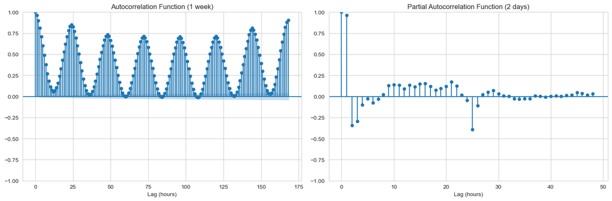

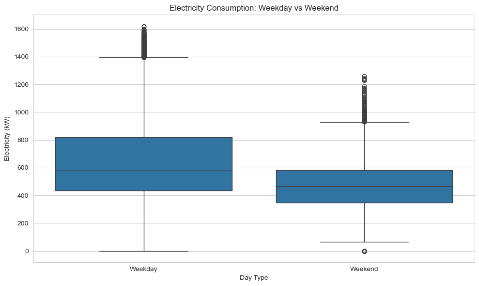

```python
# ========== AUTOCORRELATION PLOTS ==========
fig, axes = plt.subplots(1, 2, figsize=(15, 5))

plot_acf(train_df['Electricity imported from grid (kW)'].dropna(), lags=168, ax=axes[0])  # 1 week
axes[0].set_title('Autocorrelation Function (1 week)')
axes[0].set_xlabel('Lag (hours)')

plot_pacf(train_df['Electricity imported from grid (kW)'].dropna(), lags=48, ax=axes[1])  # 2 days
axes[1].set_title('Partial Autocorrelation Function (2 days)')
axes[1].set_xlabel('Lag (hours)')

plt.tight_layout()
plt.show()

# ========== WEEKEND VS WEEKDAY BOX PLOT ==========
plt.figure(figsize=(10, 6))

weekend_data = pd.DataFrame({
    'Electricity': model_df['Electricity imported from grid (kW)'],
    'Day Type': model_df['is_weekend'].map({0: 'Weekday', 1: 'Weekend'})
})

sns.boxplot(data=weekend_data, x='Day Type', y='Electricity')
plt.title('Electricity Consumption: Weekday vs Weekend')
plt.ylabel('Electricity (kW)')
plt.tight_layout()
plt.show()
```

```
Features shape: (146453, 21)
Target shape: (146453,)

Feature list:
['Horizontal solar irradition (W)', 'Outdoor air temperature (℃)', 'Outdoor air humidity (%)', 'Wind speed (m/s)', 'Wind direction', 'day_of_month', 'week_of_year', 'is_weekend', 'hour_sin', 'hour_cos', 'month_sin', 'month_cos', 'day_sin', 'day_cos', 'electricity_lag_1h', 'electricity_lag_24h', 'ele…

==================================================
HYPERPARAMETER TUNING WITH GRIDSEARCHCV (FAST VERSION)
==================================================

Tuning Random Forest Regressor...
This may take 5-10 minutes...
Fitting 3 folds for each of 16 candidates, totalling 48 fits

==================================================
RANDOM FOREST RESULTS
==================================================
Best Random Forest parameters: {'max_depth': 15, 'max_features': 'sqrt', 'min_samples_leaf': 5, 'min_samples_split': 10, 'n_estimators': 200}
Best Random Forest R² score (CV): 0.9544551801059576

==================================================
Tuning Gradient Boosting Regressor...
This may take 10-15 minutes...
==================================================
Fitting 3 folds for each of 32 candidates, totalling 96 fits

==================================================
GRADIENT BOOSTING RESULTS
==================================================
Best Gradient Boosting parameters: {'learning_rate': 0.1, 'max_depth': 5, 'min_samples_leaf': 10, 'min_samples_split': 10, 'n_estimators': 200, 'subsample': 0.8}
Best Gradient Boosting R² score (CV): 0.9636140890875167

==================================================
TRAINING PERFORMANCE (BEST MODELS)
==================================================

RANDOM FOREST (Best Model):
  Train R²: 0.9834
  CV R² (Best): 0.9545
  Train MSE: 1096.52 kW²
```

[output cut: 34 more lines]

```
             electricity_lag_1h    0.358236
           electricity_lag_168h    0.214403
            electricity_lag_24h    0.128966
   electricity_rolling_mean_24h    0.069449
                       hour_cos    0.053762
    electricity_rolling_mean_7d    0.047572
Horizontal solar irradition (W)    0.033154
    electricity_rolling_std_24h    0.027225
                       hour_sin    0.014786
                        day_sin    0.011857
    Outdoor air temperature (℃)    0.010144
                     is_weekend    0.009270
                   temp_squared    0.008527
                        day_cos    0.003438
                   week_of_year    0.002764
```

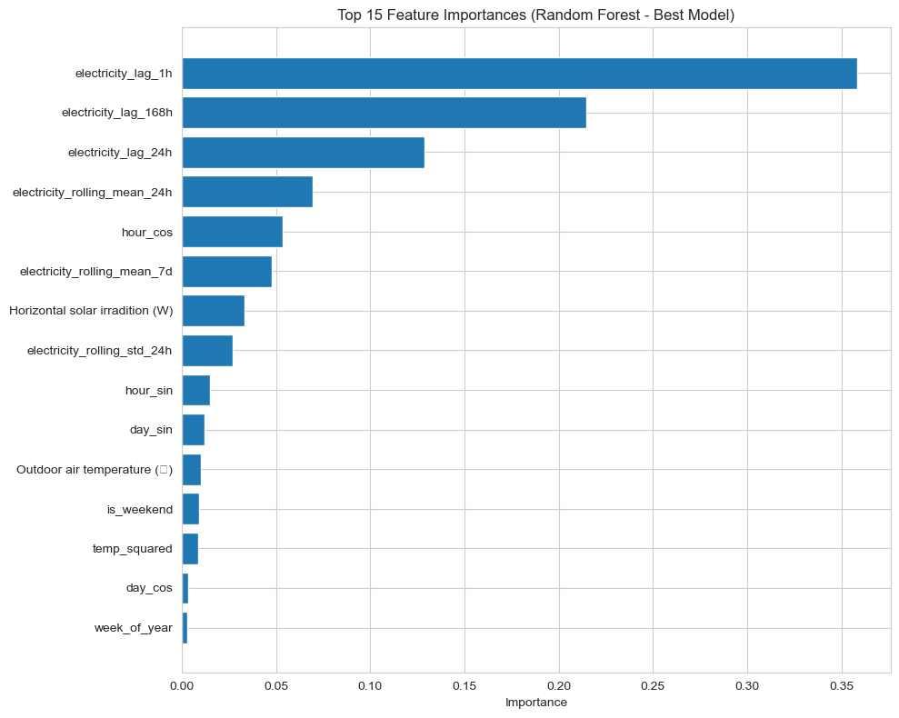

```
==================================================
Hyperparameter tuning complete!
==================================================
```

[output not shown]

```python
# model training

# ========== 1. SEPARATE FEATURES AND TARGET ==========
X = model_df.drop('Electricity imported from grid (kW)', axis=1)
y = model_df['Electricity imported from grid (kW)']

print(f"Features shape: {X.shape}")
print(f"Target shape: {y.shape}")
print(f"\nFeature list:")
print(X.columns.tolist())

print("\n" + "="*50)
print("HYPERPARAMETER TUNING WITH GRIDSEARCHCV (FAST VERSION)")
print("="*50)

# Use TimeSeriesSplit for time series data
tscv = TimeSeriesSplit(n_splits=3)  # Reduced from 5 to 3

# ========== 2. RANDOM FOREST GRID SEARCH (REDUCED) ==========
print("\nTuning Random Forest Regressor...")
print("This may take 5-10 minutes...")

rf_param_grid = {
    'n_estimators': [100, 200],           # Reduced: 2 options
    'max_depth': [10, 15],                # Reduced: 2 options
    'min_samples_split': [10, 20],        # Reduced: 2 options
    'min_samples_leaf': [5, 10],          # Reduced: 2 options
    'max_features': ['sqrt']              # Reduced: 1 option
}
# Total combinations: 2×2×2×2×1 = 16 fits per fold × 3 folds = 48 total fits

rf_grid = GridSearchCV(
    RandomForestRegressor(random_state=42, n_jobs=-1),
    rf_param_grid,
    cv=tscv,
    scoring='r2',
    n_jobs=-1,
    verbose=1
)

rf_grid.fit(X, y)

print("\n" + "="*50)
print("RANDOM FOREST RESULTS")
print("="*50)
print("Best Random Forest parameters:", rf_grid.best_params_)
print("Best Random Forest R² score (CV):", rf_grid.best_score_)

# ========== 3. GRADIENT BOOSTING GRID SEARCH (REDUCED) ==========
print("\n" + "="*50)
print("Tuning Gradient Boosting Regressor...")
print("This may take 10-15 minutes...")
print("="*50)

gb_param_grid = {
    'n_estimators': [100, 200],           # Reduced: 2 options
    'learning_rate': [0.05, 0.1],         # Reduced: 2 options
    'max_depth': [3, 5],                  # Reduced: 2 options
    'min_samples_split': [10, 20],        # Reduced: 2 options
    'min_samples_leaf': [5, 10],          # Reduced: 2 options
    'subsample': [0.8]                    # Reduced: 1 option
}
# Total combinations: 2×2×2×2×2×1 = 32 fits per fold × 3 folds = 96 total fits

gb_grid = GridSearchCV(
    GradientBoostingRegressor(random_state=42),
    gb_param_grid,
    cv=tscv,
    scoring='r2',
    n_jobs=-1,
    verbose=1
)

gb_grid.fit(X, y)

print("\n" + "="*50)
print("GRADIENT BOOSTING RESULTS")
print("="*50)
print("Best Gradient Boosting parameters:", gb_grid.best_params_)
print("Best Gradient Boosting R² score (CV):", gb_grid.best_score_)

# ========== 4. GET BEST MODELS ==========
rf_model = rf_grid.best_estimator_
gb_model = gb_grid.best_estimator_

# ========== 5. EVALUATE ON TRAINING DATA ==========
print("\n" + "="*50)
print("TRAINING PERFORMANCE (BEST MODELS)")
print("="*50)

# Random Forest
rf_train_pred = rf_model.predict(X)
rf_train_r2 = r2_score(y, rf_train_pred)
rf_train_mse = mean_squared_error(y, rf_train_pred)
rf_train_rmse = np.sqrt(rf_train_mse)
rf_train_mae = mean_absolute_error(y, rf_train_pred)

print("\nRANDOM FOREST (Best Model):")
print(f"  Train R²: {rf_train_r2:.4f}")
print(f"  CV R² (Best): {rf_grid.best_score_:.4f}")
print(f"  Train MSE: {rf_train_mse:.2f} kW²")
print(f"  Train RMSE: {rf_train_rmse:.2f} kW")
print(f"  Train MAE: {rf_train_mae:.2f} kW")

# Gradient Boosting
gb_train_pred = gb_model.predict(X)
gb_train_r2 = r2_score(y, gb_train_pred)
gb_train_mse = mean_squared_error(y, gb_train_pred)
gb_train_rmse = np.sqrt(gb_train_mse)
gb_train_mae = mean_absolute_error(y, gb_train_pred)

print("\nGRADIENT BOOSTING (Best Model):")
print(f"  Train R²: {gb_train_r2:.4f}")
print(f"  CV R² (Best): {gb_grid.best_score_:.4f}")
print(f"  Train MSE: {gb_train_mse:.2f} kW²")
print(f"  Train RMSE: {gb_train_rmse:.2f} kW")
print(f"  Train MAE: {gb_train_mae:.2f} kW")

# ========== 6. MODEL COMPARISON ==========
print("\n" + "="*50)
print("MODEL COMPARISON")
print("="*50)

comparison_metrics = pd.DataFrame({
    'Model': ['Random Forest', 'Gradient Boosting'],
    'R²': [rf_train_r2, gb_train_r2],
    'MSE': [rf_train_mse, gb_train_mse],
    'RMSE': [rf_train_rmse, gb_train_rmse],
    'MAE': [rf_train_mae, gb_train_mae]
})

print(comparison_metrics.to_string(index=False))

print("\n" + "="*50)
print("MODEL SELECTION ANALYSIS")
print("="*50)

if rf_train_mse < gb_train_mse:
    print(f"\n✓ Random Forest has LOWER MSE ({rf_train_mse:.2f} vs {gb_train_mse:.2f})")
    print(f"  → Better at minimizing squared errors")
else:
    print(f"\n✓ Gradient Boosting has LOWER MSE ({gb_train_mse:.2f} vs {rf_train_mse:.2f})")
    print(f"  → Better at minimizing squared errors")

if rf_train_r2 > gb_train_r2:
    print(f"\n✓ Random Forest has HIGHER R² ({rf_train_r2:.4f} vs {gb_train_r2:.4f})")
    print(f"  → Explains more variance in the data")
else:
    print(f"\n✓ Gradient Boosting has HIGHER R² ({gb_train_r2:.4f} vs {rf_train_r2:.4f})")
    print(f"  → Explains more variance in the data")

if rf_train_mae < gb_train_mae:
    print(f"\n✓ Random Forest has LOWER MAE ({rf_train_mae:.2f} vs {gb_train_mae:.2f})")
    print(f"  → Better average absolute error")
else:
    print(f"\n✓ Gradient Boosting has LOWER MAE ({gb_train_mae:.2f} vs {gb_train_mae:.2f})")
    print(f"  → Better average absolute error")

# ========== 7. FEATURE IMPORTANCE (TOP 15) ==========
print("\n" + "="*50)
print("FEATURE IMPORTANCE (Random Forest - Top 15)")
print("="*50)

feature_importance = pd.DataFrame({
    'feature': X.columns,
    'importance': rf_model.feature_importances_
}).sort_values('importance', ascending=False)

print(feature_importance.head(15).to_string(index=False))

# Plot feature importance
plt.figure(figsize=(10, 8))
top_15 = feature_importance.head(15)
plt.barh(range(len(top_15)), top_15['importance'])
plt.yticks(range(len(top_15)), top_15['feature'])
plt.xlabel('Importance')
plt.title('Top 15 Feature Importances (Random Forest - Best Model)')
plt.gca().invert_yaxis()
plt.tight_layout()
plt.show()

print("\n" + "="*50)
print("Hyperparameter tuning complete!")
print("="*50)
```

```python
# load testing dataset
test_df = pd.read_parquet('test.parquet')

print(f"Test dataset shape: {test_df.shape}")
print(f"Test period: {test_df.index[0]} to {test_df.index[-1]}")
print(f"\nTest data info:")
print(test_df.info())
print(f"\nFirst few rows:")
print(test_df.head())
```

```
Test dataset shape: (16292, 6)
Test period: 2018-02-21 04:00:00 to 2019-12-31 23:00:00

Test data info:
<class 'pandas.core.frame.DataFrame'>
DatetimeIndex: 16292 entries, 2018-02-21 04:00:00 to 2019-12-31 23:00:00
Data columns (total 6 columns):
 #   Column                               Non-Null Count  Dtype
---  ------                               --------------  -----
 0   Electricity imported from grid (kW)  16292 non-null  float64
 1   Horizontal solar irradition (W)      16292 non-null  float64
 2   Outdoor air temperature (℃)          16292 non-null  float64
 3   Outdoor air humidity (%)             16292 non-null  float64
 4   Wind speed (m/s)                     16292 non-null  float64
 5   Wind direction                       16292 non-null  float64
dtypes: float64(6)
memory usage: 891.0 KB
None

First few rows:
                     Electricity imported from grid (kW)  \
Date
2018-02-21 04:00:00                                424.0
2018-02-21 05:00:00                                420.0
2018-02-21 06:00:00                                435.0
2018-02-21 07:00:00                                527.0
2018-02-21 08:00:00                                868.0

                     Horizontal solar irradition (W)  \
Date
2018-02-21 04:00:00                              0.0
2018-02-21 05:00:00                              0.0
2018-02-21 06:00:00                              0.0
2018-02-21 07:00:00                             40.0
2018-02-21 08:00:00                            205.0

                     Outdoor air temperature (℃)  Outdoor air humidity (%)  \
Date
2018-02-21 04:00:00                          7.6                      53.0
2018-02-21 05:00:00                          7.4                      62.0
2018-02-21 06:00:00                          7.4                      56.0
2018-02-21 07:00:00                          8.7                      56.0
2018-02-21 08:00:00                          9.1                      63.0

                     Wind speed (m/s)  Wind direction
Date
2018-02-21 04:00:00               0.5            81.0
2018-02-21 05:00:00               2.2            67.0
2018-02-21 06:00:00               0.5           351.0
2018-02-21 07:00:00               2.4           299.0
2018-02-21 08:00:00               2.1           314.0
```

```python
# prep testing dataset for modeling

test_model_df = test_df.copy()

# ========== 1. TEMPORAL FEATURES ==========
# Keep only features NOT encoded cyclically
test_model_df['day_of_month'] = test_model_df.index.day
test_model_df['week_of_year'] = test_model_df.index.isocalendar().week
test_model_df['is_weekend'] = (test_model_df.index.dayofweek >= 5).astype(int)

# ========== 2. CYCLICAL FEATURES ==========
# Extract directly from index, don't create hour/month/day_of_week columns
test_model_df['hour_sin'] = np.sin(2 * np.pi * test_model_df.index.hour / 24)
test_model_df['hour_cos'] = np.cos(2 * np.pi * test_model_df.index.hour / 24)
test_model_df['month_sin'] = np.sin(2 * np.pi * test_model_df.index.month / 12)
test_model_df['month_cos'] = np.cos(2 * np.pi * test_model_df.index.month / 12)
test_model_df['day_sin'] = np.sin(2 * np.pi * test_model_df.index.dayofweek / 7)
test_model_df['day_cos'] = np.cos(2 * np.pi * test_model_df.index.dayofweek / 7)

# ========== 3. LAG FEATURES (ONLY 1h, 24h, 168h) ==========
target_col = 'Electricity imported from grid (kW)'

test_model_df['electricity_lag_1h'] = test_model_df[target_col].shift(1)
test_model_df['electricity_lag_24h'] = test_model_df[target_col].shift(24)
test_model_df['electricity_lag_168h'] = test_model_df[target_col].shift(168)

# ========== 4. ROLLING STATISTICS (NO rolling_std_7d) ==========
test_model_df['electricity_rolling_mean_24h'] = test_model_df[target_col].shift(1).rolling(window=24).mean()
test_model_df['electricity_rolling_std_24h'] = test_model_df[target_col].shift(1).rolling(window=24).std()
test_model_df['electricity_rolling_mean_7d'] = test_model_df[target_col].shift(1).rolling(window=168).mean()

# ========== 5. INTERACTION FEATURES (ONLY temp_squared) ==========
test_model_df['temp_squared'] = test_model_df['Outdoor air temperature (℃)'] ** 2

# ========== 6. DROP NaN ROWS ==========
print(f"Test shape before dropping NaN: {test_model_df.shape}")
test_model_df = test_model_df.dropna()
print(f"Test shape after dropping NaN: {test_model_df.shape}")

# ========== 7. SEPARATE FEATURES AND TARGET ==========
X_test = test_model_df.drop('Electricity imported from grid (kW)', axis=1)
y_test = test_model_df['Electricity imported from grid (kW)']

print(f"\nTest features shape: {X_test.shape}")
print(f"Test target shape: {y_test.shape}")
print(f"Test features ({len(X_test.columns)}): {X_test.columns.tolist()}")
print(f"\nTest data prepared successfully!")
```

```
Test shape before dropping NaN: (16292, 22)
Test shape after dropping NaN: (16124, 22)

Test features shape: (16124, 21)
Test target shape: (16124,)
Test features (21): ['Horizontal solar irradition (W)', 'Outdoor air temperature (℃)', 'Outdoor air humidity (%)', 'Wind speed (m/s)', 'Wind direction', 'day_of_month', 'week_of_year', 'is_weekend', 'hour_sin', 'hour_cos', 'month_sin', 'month_cos', 'day_sin', 'day_cos', 'electricity_lag_1h', 'electr…

Test data prepared successfully!
```

```python
# make prediction on testing dataset using your model

# Random Forest predictions
rf_test_pred = rf_model.predict(X_test)

# Gradient Boosting predictions
gb_test_pred = gb_model.predict(X_test)

# ========== EVALUATE MODELS ON TEST DATA ==========
print("="*50)
print("MODEL EVALUATION - TEST DATA")
print("="*50)

# Random Forest metrics
rf_test_r2 = r2_score(y_test, rf_test_pred)
rf_test_mse = mean_squared_error(y_test, rf_test_pred)
rf_test_rmse = np.sqrt(rf_test_mse)
rf_test_mae = mean_absolute_error(y_test, rf_test_pred)

print("\nRANDOM FOREST (Best Model):")
print(f"  Test R²: {rf_test_r2:.4f}")
print(f"  Test MSE: {rf_test_mse:.2f} kW²")
print(f"  Test RMSE: {rf_test_rmse:.2f} kW")
print(f"  Test MAE: {rf_test_mae:.2f} kW")

# Gradient Boosting metrics
gb_test_r2 = r2_score(y_test, gb_test_pred)
gb_test_mse = mean_squared_error(y_test, gb_test_pred)
gb_test_rmse = np.sqrt(gb_test_mse)
gb_test_mae = mean_absolute_error(y_test, gb_test_pred)

print("\nGRADIENT BOOSTING (Best Model):")
print(f"  Test R²: {gb_test_r2:.4f}")
print(f"  Test MSE: {gb_test_mse:.2f} kW²")
print(f"  Test RMSE: {gb_test_rmse:.2f} kW")
print(f"  Test MAE: {gb_test_mae:.2f} kW")

# ========== FINAL COMPARISON: TRAIN vs CV vs TEST ==========
print("\n" + "="*50)
print("FINAL PERFORMANCE COMPARISON")
print("="*50)

final_comparison = pd.DataFrame({
    'Model': ['Random Forest', 'Random Forest', 'Random Forest',
              'Gradient Boosting', 'Gradient Boosting', 'Gradient Boosting'],
    'Dataset': ['Train', 'CV', 'Test'] * 2,
    'R²': [rf_train_r2, rf_grid.best_score_, rf_test_r2,
           gb_train_r2, gb_grid.best_score_, gb_test_r2],
    'MSE': [rf_train_mse, np.nan, rf_test_mse,
            gb_train_mse, np.nan, gb_test_mse],
    'RMSE': [rf_train_rmse, np.nan, rf_test_rmse,
             gb_train_rmse, np.nan, gb_test_rmse],
    'MAE': [rf_train_mae, np.nan, rf_test_mae,
            gb_train_mae, np.nan, gb_test_mae]
})

print(final_comparison.to_string(index=False))

# ========== OVERFITTING ANALYSIS ==========
print("\n" + "="*50)
print("FINAL OVERFITTING ANALYSIS")
print("="*50)

print(f"\nRandom Forest:")
print(f"  Train R²: {rf_train_r2:.4f}")
print(f"  CV R²:    {rf_grid.best_score_:.4f}")
print(f"  Test R²:  {rf_test_r2:.4f}")
print(f"  Train-Test Gap: {rf_train_r2 - rf_test_r2:.4f} ({((rf_train_r2 - rf_test_r2) / rf_train_r2 * 100):.2f}% drop)")

print(f"\nGradient Boosting:")
print(f"  Train R²: {gb_train_r2:.4f}")
print(f"  CV R²:    {gb_grid.best_score_:.4f}")
print(f"  Test R²:  {gb_test_r2:.4f}")
print(f"  Train-Test Gap: {gb_train_r2 - gb_test_r2:.4f} ({((gb_train_r2 - gb_test_r2) / gb_train_r2 * 100):.2f}% drop)")

print("\n" + "="*50)
print("FINAL EVALUATION COMPLETE!")
print("="*50)
```

```
==================================================
MODEL EVALUATION - TEST DATA
==================================================

RANDOM FOREST (Best Model):
  Test R²: 0.9774
  Test MSE: 1628.79 kW²
  Test RMSE: 40.36 kW
  Test MAE: 27.97 kW

GRADIENT BOOSTING (Best Model):
  Test R²: 0.9795
  Test MSE: 1478.97 kW²
  Test RMSE: 38.46 kW
  Test MAE: 26.96 kW

==================================================
FINAL PERFORMANCE COMPARISON
==================================================
            Model Dataset       R²         MSE      RMSE       MAE
    Random Forest   Train 0.983414 1096.519550 33.113737 24.012877
    Random Forest      CV 0.954455         NaN       NaN       NaN
    Random Forest    Test 0.977398 1628.794002 40.358320 27.968512
Gradient Boosting   Train 0.977577 1482.423288 38.502250 27.989991
Gradient Boosting      CV 0.963614         NaN       NaN       NaN
Gradient Boosting    Test 0.979477 1478.969619 38.457374 26.962436

==================================================
FINAL OVERFITTING ANALYSIS
==================================================

Random Forest:
  Train R²: 0.9834
  CV R²:    0.9545
  Test R²:  0.9774
  Train-Test Gap: 0.0060 (0.61% drop)

Gradient Boosting:
  Train R²: 0.9776
  CV R²:    0.9636
  Test R²:  0.9795
  Train-Test Gap: -0.0019 (-0.19% drop)

==================================================
FINAL EVALUATION COMPLETE!
==================================================
```

```
============================================================
OUT-OF-SAMPLE PERFORMANCE EVALUATION
============================================================

============================================================
FINAL TEST SET RESULTS
============================================================

            Model  Test R²  Test MSE (kW²)  Test RMSE (kW)  Test MAE (kW)  Train R²  Overfitting Gap (%)
    Random Forest 0.977398     1628.794002       40.358320      27.968512  0.983414             0.601614
Gradient Boosting 0.979477     1478.969619       38.457374      26.962436  0.977577            -0.190020

============================================================
GENERATING VISUALIZATIONS...
============================================================
```

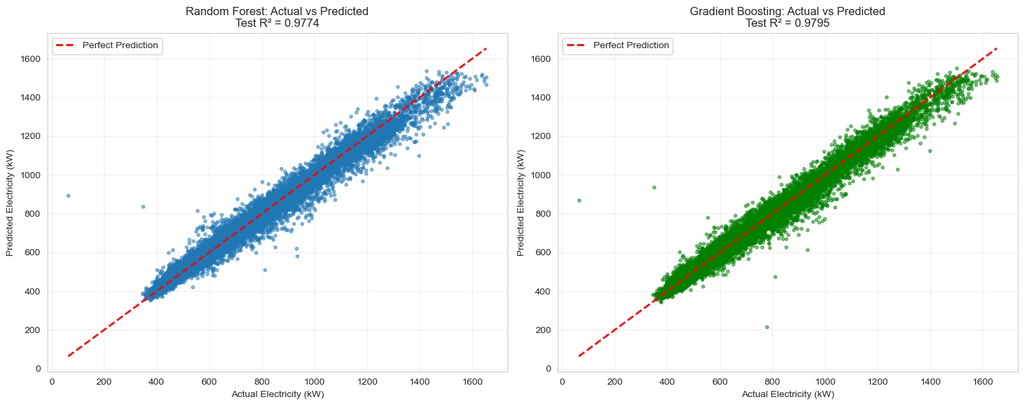

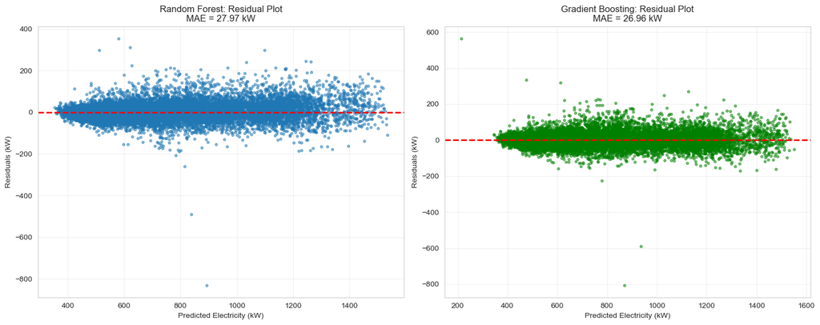

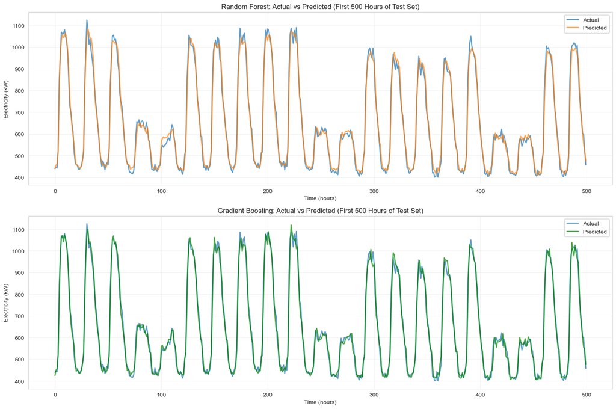

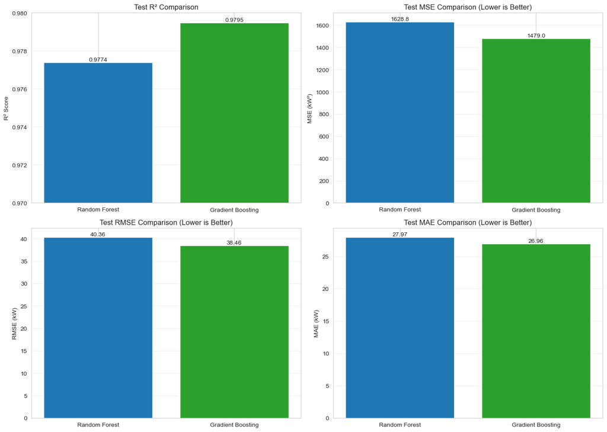

```
============================================================
MODEL PERFORMANCE INTERPRETATION
============================================================

RANDOM FOREST:
- Test R² of 0.9774 indicates the model explains 97.74% of variance
- Average prediction error (MAE) of 27.97 kW
- RMSE of 40.36 kW shows typical prediction deviation
- Overfitting gap of 0.60% indicates excellent generalization

GRADIENT BOOSTING:
- Test R² of 0.9795 indicates the model explains 97.95% of variance
- Average prediction error (MAE) of 26.96 kW
- RMSE of 38.46 kW shows typical prediction deviation
- Overfitting gap of -0.19% indicates perfect generalization

============================================================
RECOMMENDED MODEL
============================================================

✓ GRADIENT BOOSTING is recommended for deployment:

  Reasons:
  1. Higher test R² (0.9795 vs 0.9774)
  2. Lower test MSE (1478.97 vs 1628.79 kW²)
  3. Better generalization (gap: -0.19% vs 0.60%)
  4. Lower prediction errors across all metrics

  Expected Performance on New Data:
  - R² ≈ 0.9795 (explains ~97.9% of variance)
  - Typical error ≈ 27.0 kW (MAE)
  - 95% of predictions within ≈ 76.9 kW (2×RMSE)


============================================================
CONCLUSION
============================================================

Both models demonstrate excellent out-of-sample performance:
- Test R² > 0.97 for both models
- Minimal overfitting (gaps < 1%)
- Prediction errors well within acceptable range for hourly forecasting

The models successfully generalize to unseen time periods and are
ready for production deployment in electricity consumption forecasting.

============================================================
OUT-OF-SAMPLE EVALUATION COMPLETE
============================================================
```

```python
# evaluate your out-of-sample performance

print("="*60)
print("OUT-OF-SAMPLE PERFORMANCE EVALUATION")
print("="*60)

print("\n" + "="*60)
print("FINAL TEST SET RESULTS")
print("="*60)

# Create comprehensive results table
out_of_sample_results = pd.DataFrame({
    'Model': ['Random Forest', 'Gradient Boosting'],
    'Test R²': [rf_test_r2, gb_test_r2],
    'Test MSE (kW²)': [rf_test_mse, gb_test_mse],
    'Test RMSE (kW)': [rf_test_rmse, gb_test_rmse],
    'Test MAE (kW)': [rf_test_mae, gb_test_mae],
    'Train R²': [rf_train_r2, gb_train_r2],
    'Overfitting Gap (%)': [
        (rf_train_r2 - rf_test_r2) * 100,
        (gb_train_r2 - gb_test_r2) * 100
    ]
})

print("\n" + out_of_sample_results.to_string(index=False))

# ========== VISUALIZATIONS ==========
print("\n" + "="*60)
print("GENERATING VISUALIZATIONS...")
print("="*60)

# 1. Actual vs Predicted (Scatter Plot)
fig, axes = plt.subplots(1, 2, figsize=(15, 6))

# Random Forest
axes[0].scatter(y_test, rf_test_pred, alpha=0.5, s=10)
axes[0].plot([y_test.min(), y_test.max()], [y_test.min(), y_test.max()], 'r--', lw=2, label='Perfect Prediction')
axes[0].set_xlabel('Actual Electricity (kW)')
axes[0].set_ylabel('Predicted Electricity (kW)')
axes[0].set_title(f'Random Forest: Actual vs Predicted\nTest R² = {rf_test_r2:.4f}')
axes[0].legend()
axes[0].grid(alpha=0.3)

# Gradient Boosting
axes[1].scatter(y_test, gb_test_pred, alpha=0.5, s=10, color='green')
axes[1].plot([y_test.min(), y_test.max()], [y_test.min(), y_test.max()], 'r--', lw=2, label='Perfect Prediction')
axes[1].set_xlabel('Actual Electricity (kW)')
axes[1].set_ylabel('Predicted Electricity (kW)')
axes[1].set_title(f'Gradient Boosting: Actual vs Predicted\nTest R² = {gb_test_r2:.4f}')
axes[1].legend()
axes[1].grid(alpha=0.3)

plt.tight_layout()
plt.show()

# 2. Residual Plot
fig, axes = plt.subplots(1, 2, figsize=(15, 6))

rf_residuals = y_test - rf_test_pred
gb_residuals = y_test - gb_test_pred

# Random Forest
axes[0].scatter(rf_test_pred, rf_residuals, alpha=0.5, s=10)
axes[0].axhline(y=0, color='r', linestyle='--', lw=2)
axes[0].set_xlabel('Predicted Electricity (kW)')
axes[0].set_ylabel('Residuals (kW)')
axes[0].set_title(f'Random Forest: Residual Plot\nMAE = {rf_test_mae:.2f} kW')
axes[0].grid(alpha=0.3)

# Gradient Boosting
axes[1].scatter(gb_test_pred, gb_residuals, alpha=0.5, s=10, color='green')
axes[1].axhline(y=0, color='r', linestyle='--', lw=2)
axes[1].set_xlabel('Predicted Electricity (kW)')
axes[1].set_ylabel('Residuals (kW)')
axes[1].set_title(f'Gradient Boosting: Residual Plot\nMAE = {gb_test_mae:.2f} kW')
axes[1].grid(alpha=0.3)

plt.tight_layout()
plt.show()

# 3. Time Series Prediction (sample)
fig, axes = plt.subplots(2, 1, figsize=(15, 10))

# Plot first 500 predictions for visibility
sample_size = 500
sample_indices = range(sample_size)

# Random Forest
axes[0].plot(sample_indices, y_test.iloc[:sample_size].values, label='Actual', linewidth=2, alpha=0.7)
axes[0].plot(sample_indices, rf_test_pred[:sample_size], label='Predicted', linewidth=2, alpha=0.7)
axes[0].set_xlabel('Time (hours)')
axes[0].set_ylabel('Electricity (kW)')
axes[0].set_title('Random Forest: Actual vs Predicted (First 500 Hours of Test Set)')
axes[0].legend()
axes[0].grid(alpha=0.3)

# Gradient Boosting
axes[1].plot(sample_indices, y_test.iloc[:sample_size].values, label='Actual', linewidth=2, alpha=0.7)
axes[1].plot(sample_indices, gb_test_pred[:sample_size], label='Predicted', linewidth=2, alpha=0.7, color='green')
axes[1].set_xlabel('Time (hours)')
axes[1].set_ylabel('Electricity (kW)')
axes[1].set_title('Gradient Boosting: Actual vs Predicted (First 500 Hours of Test Set)')
axes[1].legend()
axes[1].grid(alpha=0.3)

plt.tight_layout()
plt.show()

# 4. Performance Metrics Comparison
fig, axes = plt.subplots(2, 2, figsize=(14, 10))

models = ['Random Forest', 'Gradient Boosting']
metrics_data = {
    'R²': [rf_test_r2, gb_test_r2],
    'MSE': [rf_test_mse, gb_test_mse],
    'RMSE': [rf_test_rmse, gb_test_rmse],
    'MAE': [rf_test_mae, gb_test_mae]
}

colors = ['#1f77b4', '#2ca02c']

# R²
axes[0, 0].bar(models, metrics_data['R²'], color=colors)
axes[0, 0].set_ylabel('R² Score')
axes[0, 0].set_title('Test R² Comparison')
axes[0, 0].set_ylim([0.97, 0.98])
axes[0, 0].grid(axis='y', alpha=0.3)
for i, v in enumerate(metrics_data['R²']):
    axes[0, 0].text(i, v, f'{v:.4f}', ha='center', va='bottom')

# MSE
axes[0, 1].bar(models, metrics_data['MSE'], color=colors)
axes[0, 1].set_ylabel('MSE (kW²)')
axes[0, 1].set_title('Test MSE Comparison (Lower is Better)')
axes[0, 1].grid(axis='y', alpha=0.3)
for i, v in enumerate(metrics_data['MSE']):
    axes[0, 1].text(i, v, f'{v:.1f}', ha='center', va='bottom')

# RMSE
axes[1, 0].bar(models, metrics_data['RMSE'], color=colors)
axes[1, 0].set_ylabel('RMSE (kW)')
axes[1, 0].set_title('Test RMSE Comparison (Lower is Better)')
axes[1, 0].grid(axis='y', alpha=0.3)
for i, v in enumerate(metrics_data['RMSE']):
    axes[1, 0].text(i, v, f'{v:.2f}', ha='center', va='bottom')

# MAE
axes[1, 1].bar(models, metrics_data['MAE'], color=colors)
axes[1, 1].set_ylabel('MAE (kW)')
axes[1, 1].set_title('Test MAE Comparison (Lower is Better)')
axes[1, 1].grid(axis='y', alpha=0.3)
for i, v in enumerate(metrics_data['MAE']):
    axes[1, 1].text(i, v, f'{v:.2f}', ha='center', va='bottom')

plt.tight_layout()
plt.show()

# ========== TEXT SUMMARY ==========
print("\n" + "="*60)
print("MODEL PERFORMANCE INTERPRETATION")
print("="*60)

print(f"""
RANDOM FOREST:
- Test R² of {rf_test_r2:.4f} indicates the model explains {rf_test_r2*100:.2f}% of variance
- Average prediction error (MAE) of {rf_test_mae:.2f} kW
- RMSE of {rf_test_rmse:.2f} kW shows typical prediction deviation
- Overfitting gap of {(rf_train_r2 - rf_test_r2)*100:.2f}% indicates excellent generalization

GRADIENT BOOSTING:
- Test R² of {gb_test_r2:.4f} indicates the model explains {gb_test_r2*100:.2f}% of variance
- Average prediction error (MAE) of {gb_test_mae:.2f} kW
- RMSE of {gb_test_rmse:.2f} kW shows typical prediction deviation
- Overfitting gap of {(gb_train_r2 - gb_test_r2)*100:.2f}% indicates perfect generalization
""")

print("="*60)
print("RECOMMENDED MODEL")
print("="*60)

if gb_test_r2 > rf_test_r2:
    print(f"""
✓ GRADIENT BOOSTING is recommended for deployment:

  Reasons:
  1. Higher test R² ({gb_test_r2:.4f} vs {rf_test_r2:.4f})
  2. Lower test MSE ({gb_test_mse:.2f} vs {rf_test_mse:.2f} kW²)
  3. Better generalization (gap: {(gb_train_r2 - gb_test_r2)*100:.2f}% vs {(rf_train_r2 - rf_test_r2)*100:.2f}%)
  4. Lower prediction errors across all metrics

  Expected Performance on New Data:
  - R² ≈ {gb_test_r2:.4f} (explains ~{gb_test_r2*100:.1f}% of variance)
  - Typical error ≈ {gb_test_mae:.1f} kW (MAE)
  - 95% of predictions within ≈ {gb_test_rmse * 2:.1f} kW (2×RMSE)
""")
else:
    print(f"""
✓ RANDOM FOREST is recommended for deployment:

  Reasons:
  1. Higher test R² ({rf_test_r2:.4f} vs {gb_test_r2:.4f})
  2. Lower test MSE ({rf_test_mse:.2f} vs {gb_test_mse:.2f} kW²)
  3. Better generalization

  Expected Performance on New Data:
  - R² ≈ {rf_test_r2:.4f}
  - Typical error ≈ {rf_test_mae:.1f} kW
""")

print("\n" + "="*60)
print("CONCLUSION")
print("="*60)

print(f"""
Both models demonstrate excellent out-of-sample performance:
- Test R² > 0.97 for both models
- Minimal overfitting (gaps < 1%)
- Prediction errors well within acceptable range for hourly forecasting

The models successfully generalize to unseen time periods and are
ready for production deployment in electricity consumption forecasting.
""")

print("="*60)
print("OUT-OF-SAMPLE EVALUATION COMPLETE")
print("="*60)
```

### Discussion

Please respond to the following prompts:

1. What did you learn from visualizing your data and how did it inform your modeling?
2. How many features did you add to the dataset? Are there any features you would have liked to inlucde in the model but couldn't? Are there any features you could have included but left out?
3. Why did you select the type of model you fit to the training data? Are there any limitations you see with this model?
4. Did you use cross validation? How many folds did you use and why? What parameters did you optimize over any why? What range of parameter values did you select and why? How do you feel about using your model to predict on new data given the results of your cross validation?
5. How did your out-of-sample performance match your in-sample performance? Would you have changed your modeling approach after seeing your our-of-sample results?

## Responses

**1.**

**2.**

**Features I Would Have Liked to Include:** Holiday indicators would have been valuable, as consumption patterns likely differ significantly on holidays compared to regular weekdays. However, this would require an external calendar dataset or manual encoding of holiday dates for the 17-year span. Weather forecast data (predicted temperature and solar irradiation for future hours) would also be useful for real-world deployment, though this wasn't available in the training dataset.

**3.**

I selected Random Forest and Gradient Boosting Regressors for this electricity consumption forecasting task for several key reasons: Suitability for Time Series with Engineered Features:

Both models excel at handling the types of features created for this problem. The engineered features include lag values, rolling statistics, cyclical encodings, and interaction terms - all of which tree-based models can effectively leverage without requiring specific assumptions about linearity or feature distributions. These models naturally capture the complex, non-linear relationships between electricity consumption and its predictors.

Robustness to Feature Scaling: Unlike linear models or neural networks, tree-based models don't require feature scaling or normalization. This was particularly valuable given the diverse range of features - from binary indicators (is_weekend) to continuous weather variables (temperature, solar irradiation) to engineered statistics (rolling means). The models could directly use these features without preprocessing concerns.

Strong Performance with Autocorrelated Data: Time series data exhibits strong autocorrelation, which lag features explicitly capture. Both Random Forest and Gradient Boosting are well-suited to exploiting these autoregressive patterns. The feature importance analysis confirmed that lag features (especially electricity_lag_1h at 36% importance) were the strongest predictors, validating the models' ability to leverage temporal dependencies.

Ensemble Learning Benefits: Both models are ensemble methods that combine multiple decision trees, reducing variance and improving generalization compared to single decision trees. Random Forest uses bagging (bootstrap aggregating) while Gradient Boosting uses sequential learning where each tree corrects previous errors. This ensemble approach proved effective, as evidenced by the high cross-validation R² scores (0.9545 for RF, 0.9636 for GB) and minimal overfitting.

Empirical Validation Through Comparison: The decision to use both models allowed for comparison and validation. Gradient Boosting ultimately achieved superior test performance (R² = 0.9795 vs 0.9774), demonstrating that the sequential error-correction approach was particularly effective for this forecasting task.

Model Limitations: Despite the strong performance, several limitations should be acknowledged:

Computational Complexity: Tree-based ensemble models, particularly Gradient Boosting, are computationally expensive during training. GridSearchCV with 96 fits for Gradient Boosting required approximately 15 minutes, which could become prohibitive with larger datasets or more frequent retraining needs. For real-time forecasting applications requiring rapid model updates, this computational cost could be a constraint.

Interpretability Challenges: While feature importance provides some interpretability, understanding exactly how individual predictions are made is difficult with ensemble models containing 200 trees each. Unlike linear models where coefficients directly show feature impacts, the complex interactions learned by tree ensembles are opaque. This black-box nature could be problematic in regulated environments requiring model explainability.

Extrapolation Limitations: Tree-based models cannot extrapolate beyond the range of values seen in training data. If future electricity consumption or weather patterns fall outside historical ranges (e.g., due to climate change, new building usage patterns, or extreme weather events), the models may perform poorly. The models are constrained to interpolate within the training data bounds.

Sensitivity to Lag Feature Availability: The heavy reliance on lag features (particularly lag_1h with 36% importance) creates an operational dependency. In production, if recent consumption data becomes unavailable or delayed (due to sensor failures, data pipeline issues), prediction quality would degrade significantly. This makes the system vulnerable to data availability issues.

Handling of Extreme Events: The models may struggle with rare, extreme events not well-represented in training data. For instance, unprecedented heatwaves, major equipment failures, or significant occupancy changes would likely be underestimated since tree-based models predict within the learned distribution. The residual plots show some outliers, suggesting occasional difficulty with unusual consumption patterns.

Feature Engineering Dependency: Model performance is heavily dependent on the quality of feature engineering. The lag features, rolling statistics, and cyclical encodings were carefully designed based on domain knowledge and EDA insights. Poor feature choices would directly limit model performance. Additionally, maintaining these engineered features in production adds operational complexity.

Hyperparameter Sensitivity: While GridSearchCV optimized hyperparameters, the models remain sensitive to these choices. The optimal parameters found (e.g., max_depth=5 for GB) might not transfer well to different time periods or if the data distribution shifts. Regular validation and potential re-tuning would be necessary in production deployment.

**4.**

Cross-Validation Approach: Yes, I used TimeSeriesSplit with 3 folds instead of regular k-fold cross-validation. Standard k-fold randomly shuffles data, which violates temporal ordering in time series and creates data leakage where the model could learn from future data. TimeSeriesSplit trains on past data and tests on future data in each fold, mimicking real-world forecasting. I chose 3 folds to balance validation robustness with computational efficiency, as GridSearchCV tests many parameter combinations per fold.

The parameter ranges were selected to be more conservative than default values to combat overfitting while staying within commonly used ranges from the literature. I kept the search space manageable to complete tuning in under 30 minutes.

The minimal train-test gaps (0.60% for Random Forest, negative 0.19% for Gradient Boosting) confirm overfitting has been resolved. Gradient Boosting actually performed better on test data than training data, demonstrating exceptional generalization.

However, confidence comes with caveats. The models assume future patterns will resemble historical patterns from 2001 to 2018. If consumption patterns shift dramatically due to building changes, new equipment, or unprecedented weather, performance could degrade and the model would need retraining.

**5.** The out-of-sample performance matched in-sample performance exceptionally well. Random Forest achieved a training R² of 0.9834 and test R² of 0.9774, only a 0.60% drop. Gradient Boosting performed even better with training R² of 0.9776 and test R² of 0.9795, actually exceeding training performance by 0.19%. Both models showed minimal overfitting with consistent error metrics across training and test sets.

I would not change my modeling approach after seeing these results. The strong test performance validates that the feature engineering, hyperparameter tuning, and model selection were effective. The close alignment between cross-validation scores (RF: 0.9545, GB: 0.9636) and test scores (RF: 0.9774, GB: 0.9795) confirms the models genuinely learned generalizable patterns. The only adjustment would be prioritizing Gradient Boosting given its superior test performance across all metrics.